# Get data from GZ and UAR and unite the rest:

Antonio Avila

06/02/2020

```r
library(jsonlite)
library(tidyverse)
library(rvest)
library("rgdal") # ReadOGR
library(sf)
# setwd("~/A - Estudios/LSE - Applied Social Data Science/Project/PM2.5/Data Europe/")
```

## Get data from Urban Access Regulations (webpage)

1. Read the data:

```r
uar <- read_json(path = "data/Urb. Access Reg data mapapi.txt",
                      simplifyVector = TRUE)[[1]]
# "Low Emission Zone in place since the 1st" (or similar, say the day of the beguinning.)
uar %>% head(2)
```

|  | id | citypath | introtext | cityname | city_latitude | city_longitude | scheme_color |
| --- | --- | --- | --- | --- | --- | --- | --- |
| 1 | 1213 |  | NA | Sassari | 40.80 | 8.58 | NA |
| 2 | 499 | http://urbanaccessregulations.eu/countries-mainmenu-147/italy-mainmenu-81/sicilia-region/palermo | The combined low emission zone, road charge, congestion charge and ZTL scheme has been in operation since 10 October 2016.\r\n | Palermo | 38.11 | 13.36 | 2 |

```r
uar[4:7, 2]
```

```
[1] "http://urbanaccessregulations.eu/countries-mainmenu-147/united-kingdom-mainmenu-205/mersey-river-crossings-tunnel-toll"
[2] "http://urbanaccessregulations.eu/countries-mainmenu-147/united-kingdom-mainmenu-205/london-charging-scheme"
[3] "http://urbanaccessregulations.eu/countries-mainmenu-147/norway-mainmenu-197/trondheim-charging-scheme"
[4] "http://urbanaccessregulations.eu/countries-mainmenu-147/norway-mainmenu-197/oslo-charging-scheme"
```

```r
# I could make a scraper that goes to every page and gets more information.

# From the "introtext" I colud also get some information about when it started:
uar$introtext[2] %>% cat()
```

```
The combined low emission zone, road charge, congestion charge and ZTL scheme has been in operation since 10 October 2016.
```

Note: Look if I can scrape more info from the pages or descriptions.

Get the meanings of the colours:

https://urbanaccessregulations.eu/userhome/map#car

```r
uar <- uar %>%
  mutate(
    lez = ifelse(scheme_color == 1, TRUE, FALSE),
    urb_toll = ifelse(scheme_color == 2, TRUE, FALSE),
    other_reg = ifelse(scheme_color == 3, TRUE, FALSE),
    em_scheme = ifelse(scheme_color == 4, TRUE, FALSE),
    city_latitude = as.numeric(city_latitude),
    city_longitude = as.numeric(city_longitude),
    scheme_color = as.numeric(scheme_color)
  ) %>%
  mutate(scheme = case_when(
         scheme_color == 1 ~ "lez",
         scheme_color == 2 ~ "urban toll",
         scheme_color == 3 ~ "other regulations",
         scheme_color == 4 ~ "pollution emergency") %>% as.factor())

uar %>% head()
```

|  | id | citypath | introtext | cityname | city_latitude | city_longitude | scheme_color | lez | urb_toll | other_reg | em_scheme | scheme |
| --- | --- | --- | --- | --- | --- | --- | --- | --- | --- | --- | --- | --- |
| 1 | 1213 |  | NA | Sassari | 40.80 | 8.58 | NA | NA | NA | NA | NA | NA |
| 2 | 499 | http://urbanaccessregulations.eu/countries-mainmenu-147/italy-mainmenu-81/sicilia-region/palermo | The combined low emission zone, road charge, congestion charge and ZTL scheme has been in operation since 10 October 2016.\r\n | Palermo | 38.11 | 13.36 | 2 | FALSE | TRUE | FALSE | FALSE | urban toll |
| 3 | 490 | https://urbanaccessregulations.eu/countries-mainmenu-147/italy-mainmenu-81/milan-area-c-charging-scheme | \r\n\tThere are several schemes in Milan:\r\n\r\n\r\n\t\r\n\t\tNEW!&nbsp;Area B is a Low Emission Zone that will be activated the 25 February 2019. It will cover the entire city of Milan.\r\n\t\r\n\t\… | Milano LEZ & CS | 45.47 | 9.19 | 2 | FALSE | TRUE | FALSE | FALSE | urban toll |
| 4 | 1469 | http://urbanaccessregulations.eu/countries-mainmenu-147/united-kingdom-mainmenu-205/mersey-river-crossings-tunnel-toll | \r\n\tThere are different options to cross the river Mersey in Liverpool:\r\n\r\n\r\n\t\r\n\t\tvia Mersey Gateway (bridge)\r\n\t\r\n\t\tvia Silver Jubilee Bridge&nbsp;(is closed for refurbishment unti… | Mersey River Crossings - CS | 53.40 | -2.99 | 2 | FALSE | TRUE | FALSE | FALSE | urban toll |
| 5 | 812 | http://urbanaccessregulations.eu/countries-mainmenu-147/united-kingdom-mainmenu-205/london-charging-scheme | UK-LO | London - CS | 51.51 | -0.13 | 2 | FALSE | TRUE | FALSE | FALSE | urban toll |
| 6 | 813 | http://urbanaccessregulations.eu/countries-mainmenu-147/norway-mainmenu-197/trondheim-charging-scheme | In addition, a seperate 'Low Emission Zone' is being considered for Trondheim.\r\n | Trondheim - CS | 63.44 | 10.39 | 2 | FALSE | TRUE | FALSE | FALSE | urban toll |

```r
uar %>% # All mesures are included
  filter(str_detect(uar$cityname, "Paris"))
```

| id | citypath | introtext | cityname | city_latitude | city_longitude | scheme_color | lez | urb_toll | other_reg | em_scheme | scheme |
| --- | --- | --- | --- | --- | --- | --- | --- | --- | --- | --- | --- |
| 994 | http://urbanaccessregulations.eu/countries-mainmenu-147/france/paris | There is also an Access Regulation in place in Paris\r\nParis started a monthly carfree day on the 18th May 2016. The second carfree day will take place 22th September 2017.\r\n | Paris | 48.86 | 2.35 | 1 | TRUE | FALSE | FALSE | FALSE | lez |
| 1575 | /countries-mainmenu-147/france/45-countries/france/france-lezs/116-greater-paris | ZFE | Greater Paris | 48.87 | 2.34 | 1 | TRUE | FALSE | FALSE | FALSE | lez |
| 1193 | http://urbanaccessregulations.eu/countries-mainmenu-147/france/paris-odd-even-scheme | There are a number of schemes in Paris | Paris - Emergency Scheme | 48.86 | 2.35 | 4 | FALSE | FALSE | FALSE | TRUE | pollution emergency |
| 879 | http://urbanaccessregulations.eu/countries-mainmenu-147/france/paris-ar | There is an access regulation in place in Paris concerning HGV (heavy goods vehicles) over 7.5 tonnes.\r\nThere is also an LEZ in place in Paris and Emergency Scheme in operation at times of very high… | Paris - AR | 48.86 | 2.35 | 3 | FALSE | FALSE | TRUE | FALSE | other regulations |

```r
# uar %>% dim() # Almost 700 legislations!
```

Read the scheme data

```r
# This gives me the lists of names and their Ids
allscheme <- read_json(path = "data/AllScheme.txt",
                       simplifyVector = TRUE)[[1]]
allscheme %>% head()
```

|  | id | cityname |
| --- | --- | --- |
| 1 | 160 |  |
| 2 | 1508 | A12 Air quality-based speed limit |
| 3 | 1705 |  |
| 4 | 1410 | Valletta |
| 5 | 1396 | Salzburg |
| 6 | 200 |  |

```r
# write.csv(x = uar, file = "data/UAR_data/uar.csv")
# write.csv(x = allscheme, file = "data/UAR_data/id_name_pairs.csv")
```

## Get the data grom GreenZones.eu

```r
library(DBI)
con <- dbConnect(RSQLite::SQLite(),
                 dbname = "data/Greenzonesapp/db_greenzones.db")

# Explore:
dbListTables(con)
```

```
 [1] "Euronorm"
 [2] "EuronormTranslation"
 [3] "Fahrzeugart"
 [4] "FahrzeugartEuronormMap"
 [5] "FahrzeugartKraftstoffMap"
 [6] "FahrzeugartTranslation"
 [7] "Fahrzeugkategorie"
 [8] "FahrzeugkategorieTranslation"
 [9] "Kraftstoff"
[10] "KraftstoffTranslation"
[11] "Land"
[12] "LandTranslation"
[13] "Plakette"
[14] "PlaketteTranslation"
[15] "Plakettengruppe"
```

[output cut: 20 more lines]

```r
dbListFields(con, "Land")
```

```
[1] "TitelLocal" "Bild"       "Id"
```

```r
DBI::dbGetQuery(con, "SELECT * from Zonenvorwarnung")
```

| Id | Timestamp | ZoneId | ZonenvorwarnartId | Typo3Id |
| --- | --- | --- | --- | --- |

```r
# Kraftstoff -> Fuel
# SondereigenschaftAusprägung "specifics" look at "SondereigenschaftAusprägungTranslation".
# This works with "ZoneAusnahmeMap"(Zone exception map)

# This gives which distictives can enter where:
DBI::dbGetQuery(con, "SELECT * from ZonePlaketteMap") %>% head()
```

|  | Id | ZoneId | PlaketteId |
| --- | --- | --- | --- |
| 1 | 1 | 15 | 6 |
| 2 | 2 | 15 | 5 |
| 3 | 3 | 15 | 4 |
| 4 | 4 | 15 | 9 |
| 5 | 5 | 15 | 8 |
| 6 | 6 | 15 | 7 |

```r
DBI::dbGetQuery(con, "SELECT * from Plakette") # Details and name of distinctives
```

| LandId | PlakettengruppeId | IsDefault | Bild | Id |
| --- | --- | --- | --- | --- |
| 54 | 5 | 0 | Gruene_Plakette_1000px.png | 1 |
| 54 | 5 | 0 | Gelbe_Plakette_1000px.png | 2 |
| 54 | 5 | 0 | Rote_Plakette_1000px.png | 3 |
| 13 | 4 | 0 | Pickerl_4_1000px.png | 4 |
| 13 | 4 | 0 | Pickerl_5_1000px.png | 5 |
| 13 | 4 | 0 | Pickerl_6_1000px.png | 6 |
| 13 | 4 | 0 | Pickerl_1_1000px.png | 7 |
| 13 | 4 | 0 | Pickerl_2_1000px.png | 8 |
| 13 | 4 | 0 | Pickerl_3_1000px.png | 9 |
| 56 | 7 | 0 | Ecosticker_rot_1000px.jpg | 10 |

[output cut: 18 more lines]

```r
# Vehicles:
# Types of vehicles and their category
DBI::dbGetQuery(con, "SELECT * from Fahrzeugart") %>% head()
```

|  | KategorieId | Bild | Id |
| --- | --- | --- | --- |
| 1 | 1 | MofaMoped.png | 1 |
| 2 | 1 | Motorrad.png | 2 |
| 3 | 1 | MotorradBW.png | 3 |
| 4 | 1 | DreiRadLangsamer45kmh.png | 4 |
| 5 | 1 | DreiRadSchneller45kmh.png | 5 |
| 6 | 1 | VierRadLeicht.png | 6 |

```r
zones <- DBI::dbGetQuery(con, "SELECT Zone.*, Land.TitelLocal
                         from Zone
                         LEFT JOIN Land ON Zone.LandId = Land.Id")

# Figure out the translation for datetimes:
# (PROBABLY ADD A COUPLE MORE TO INCREASE ACCURACY? WORKS PERFECT NOW...)
dates <- c("20080101", "20150901", "20190502", "20170101")
dates <- as.integer(lubridate::ymd(dates))
numbers <- c(633347424, 635766624, 636923520, 636188256)
lm_dates <- lm(dates ~ numbers, model = TRUE)
lm_dates
```

```
Call:
lm(formula = dates ~ numbers, model = TRUE)

Coefficients:
(Intercept)      numbers
 -7.192e+05    1.157e-03
```

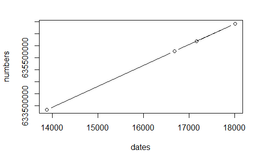

```r
plot(dates, numbers, type="b")
```

```r
zones %>% head()
```

|  | ElternzoneId | LandId | Bild | KML | MinLatitude | MaxLatitude | MinLongitude | MaxLongitude | InPlanung | InkraftSeit | Id | TitelLocal |
| --- | --- | --- | --- | --- | --- | --- | --- | --- | --- | --- | --- | --- |
| 1 | NA | 54 | DeutschlandDetailBerlin.jpg | DeutschlandBerlin.kmls | 52.46486 | 52.54979 | 13.282451 | 13.475927 | 0 | 633347424000000000 | 2 | Deutschland |
| 2 | 22 | 72 | FrankreichDetailParisZCR.jpg | FrankreichParisZCR.kmls | 48.81655 | 48.90067 | 2.253285 | 2.414331 | 0 | 635766624000000000 | 3 | France |
| 3 | 5 | 72 | FrankreichDetailGrenobleZCR.jpg | FrankreichGrenobleZCR.kmls | 45.10366 | 45.24925 | 5.658944 | 5.786253 | 0 | 636923520000000000 | 4 | France |
| 4 | 681 | 72 | FrankreichDetailGrenobleZPA.jpg | FrankreichGrenobleZPA.kmls | 44.95622 | 45.32257 | 5.569180 | 5.880396 | 0 | 636188256000000000 | 5 | France |
| 5 | NA | 72 | FrankreichDetailLyonZPA.jpg | FrankreichLyonZPA.kmls | 45.71872 | 45.81768 | 4.771916 | 4.908967 | 0 | 636170976000000000 | 6 | France |
| 6 | 460 | 72 | FrankreichDetailArveTalZPA.jpg | FrankreichArveTalZPA.kmls | 45.72307 | 46.15127 | 6.218113 | 7.044702 | 0 | 636398208000000000 | 8 | France |

```r
zones <- zones %>%
  mutate(
    InPlaceSince = lubridate::as_date(
      floor(InkraftSeit*lm_dates$coefficients[2])/1000000000 + lm_dates$coefficients[1]),
    lat = (MaxLatitude + MinLatitude)/2,
    lon = (MaxLongitude + MinLongitude)/2
    ) %>%
  select(-c("InkraftSeit"))

zones %>% head()
```

|  | ElternzoneId | LandId | Bild | KML | MinLatitude | MaxLatitude | MinLongitude | MaxLongitude | InPlanung | Id | TitelLocal | InPlaceSince | lat | lon |
| --- | --- | --- | --- | --- | --- | --- | --- | --- | --- | --- | --- | --- | --- | --- |
| 1 | NA | 54 | DeutschlandDetailBerlin.jpg | DeutschlandBerlin.kmls | 52.46486 | 52.54979 | 13.282451 | 13.475927 | 0 | 2 | Deutschland | 2008-01-01 | 52.50732 | 13.379189 |
| 2 | 22 | 72 | FrankreichDetailParisZCR.jpg | FrankreichParisZCR.kmls | 48.81655 | 48.90067 | 2.253285 | 2.414331 | 0 | 3 | France | 2015-09-01 | 48.85861 | 2.333808 |
| 3 | 5 | 72 | FrankreichDetailGrenobleZCR.jpg | FrankreichGrenobleZCR.kmls | 45.10366 | 45.24925 | 5.658944 | 5.786253 | 0 | 4 | France | 2019-05-02 | 45.17645 | 5.722599 |
| 4 | 681 | 72 | FrankreichDetailGrenobleZPA.jpg | FrankreichGrenobleZPA.kmls | 44.95622 | 45.32257 | 5.569180 | 5.880396 | 0 | 5 | France | 2017-01-01 | 45.13939 | 5.724788 |
| 5 | NA | 72 | FrankreichDetailLyonZPA.jpg | FrankreichLyonZPA.kmls | 45.71872 | 45.81768 | 4.771916 | 4.908967 | 0 | 6 | France | 2016-12-12 | 45.76820 | 4.840442 |
| 6 | 460 | 72 | FrankreichDetailArveTalZPA.jpg | FrankreichArveTalZPA.kmls | 45.72307 | 46.15127 | 6.218113 | 7.044702 | 0 | 8 | France | 2017-09-01 | 45.93717 | 6.631407 |

```r
# I could get the translation (of countries) in English too

# Hey! If the min and max longitude is faily exact it is a very good proxi for the real shapefile (maybe a circle inside the sqare is a little better)

DBI::dbDisconnect(con)
```

This was quite nice, if I want to get the geografies and more data I should look at the dll files (for which I need a compiler from Hex).

## Objective now:

Objective:

1. Merge data from all sources with one Nuts3 region as an observation and with
1. Which UAR have been applied in that zone, (DONE)
2. from when? (DONE)
3. any economical data from Eurostat. (DONE)
4. Look at sources of air pollution (TO DO)
5. Look at sources of congestion (TO DO)

### Know which zones are treated:

#### Use the coordinates to know which NUTS 3 regions are “treated” OR “not in the control” group

```r
# Source: https://ec.europa.eu/eurostat/web/gisco/geodata/reference-data/administrative-units-statistical-units/nuts
# (higher quality available)

# Read NUTS 1,2 and 3 zones from original file, filter to only nuts 2 ans 3 and correct it:
nuts.sf <- read_sf("data/NUTS3/ref-nuts-2016-01m") %>%
  select(-FID) %>%
  filter(LEVL_CODE %in% c(2, 3)) %>%
  st_make_valid()
```

[output not shown]

```r
Encoding(nuts.sf$NUTS_NAME) <- "UTF-8"

nuts.sf %>% as.data.frame() %>% head()
```

|  | LEVL_CODE | NUTS_ID | CNTR_CODE | NUTS_NAME | geometry |
| --- | --- | --- | --- | --- | --- |
| 1 | 3 | HR043 | HR | Krapinsko-zagorska županija |  |
| 2 | 2 | CH02 | CH | Espace Mittelland |  |
| 3 | 2 | CH03 | CH | Nordwestschweiz |  |
| 4 | 2 | AL02 | AL | Qender |  |
| 5 | 2 | AL03 | AL | Jug |  |
| 6 | 2 | BG33 | BG |  |  |

## Convert data from cities into geolocations:

#### From UAR:

```r
uar <- uar %>% arrange(scheme_color) # to improve the map

# (points)
uar_sf <- st_as_sf(uar, coords = c("city_longitude", "city_latitude"),
                   crs = "+proj=longlat +datum=WGS84 +no_defs")

uar_sf %>% as.data.frame() %>% head()
```

|  | id | citypath | introtext | cityname | scheme_color | lez | urb_toll | other_reg | em_scheme | scheme | geometry |
| --- | --- | --- | --- | --- | --- | --- | --- | --- | --- | --- | --- |
| 1 | 863 | http://urbanaccessregulations.eu/countries-mainmenu-147/spain/madrid-access-restriction | \r\n\tMadrid has various schemes in place:\r\n\r\n\r\n\t\r\n\t\ta low emission parking scheme&nbsp;that favours less polluting vehicles\r\n\t\r\n\t\ta low emission traffic limited zone&nbsp;vehicles h… | Madrid - ZEZ - Traffic Limited Zone | 1 | TRUE | FALSE | FALSE | FALSE | lez |  |
| 2 | 68 | http://urbanaccessregulations.eu/countries-mainmenu-147/united-kingdom-mainmenu-205/london | UK-LO | London | 1 | TRUE | FALSE | FALSE | FALSE | lez |  |
| 3 | 1691 | /countries-mainmenu-147/norway-mainmenu-197/oslo |  | Oslo | 1 | TRUE | FALSE | FALSE | FALSE | lez |  |
| 4 | 1677 |  | Greater Manchester Combined Authority (GMCA) has confirmed that there will be a Clean Air Zone (CAZ) from 2021. | Greater Manchester | 1 | TRUE | FALSE | FALSE | FALSE | lez |  |
| 5 | 123 | http://urbanaccessregulations.eu/countries-mainmenu-147/austria-mainmenu-78/a12-motorway-tirol | On the A12 there are several schemes, please select the one you want information on, and then the details will show below | A12 Motorway (Tirol) | 1 | TRUE | FALSE | FALSE | FALSE | lez |  |
| 6 | 142 | http://urbanaccessregulations.eu/countries-mainmenu-147/netherlands-mainmenu-88/breda | Breda has had a Low Emission Zone in place since the 5th October 2007. | Breda | 1 | TRUE | FALSE | FALSE | FALSE | lez |  |

**Restrict UAR to “Real” controls and not every kind of access regulations:**

(info from https://urbanaccessregulations.eu/userhome/map)

- Delete all access regulations in Poland (other access regulations are very week and LEZ in krakovia is implemented after 2018)
- delete all access regulations in
  - Bucarest, Budapest, Sofía, Suceava, Salsburg
    - (very week, only to heavy trucks > 5 to 8 tones)
- delete all pollution emergency schemes (only 5-10 that do not coincide with a LEZ) (I am looking at average pollution)
- try to eliminate as much “late” LEZ:
  - Barcelona
- try to eliminate as much “week” "other urban access regulations:
  - Dublin (only heavy vehicles),
  - Groningen (only 1 pedestrian street)
  - Würzburg (only heavy ~ >3.5T vehicles)

```r
uar_sf <- uar_sf %>%
  # Delete cities that I have reviewed the regulations are very week
  filter(!str_detect(cityname, "Budapest"),
         !str_detect(cityname, "Sofia"),
         !str_detect(cityname, "Bucharest"),
         !str_detect(cityname, "Suceava"),
         !str_detect(cityname, "Salzburg"),
         !str_detect(cityname, "Dublin"),
         !str_detect(cityname, "Groningen"),
         !str_detect(cityname, "Würzburg"),
         # Polish cities
         !str_detect(cityname, "Poznan"),
         !str_detect(cityname, "Wroclaw"),
         !str_detect(cityname, "Lodz"),
         !str_detect(cityname, "Gdynia"),
         !str_detect(cityname, "Warsawa"),
         # UK cities
         !str_detect(cityname, "Norwich"),#  (only an old castle)
         !str_detect(cityname, "Leicester"),#  LEZ (planned in 2026)
         !str_detect(cityname, "Manchester"),#  (planned by 2021)
         !str_detect(cityname, "Mersey River"),# Mersey River Crossings
         !str_detect(cityname, "Leeds"),#  (supposed 2020, now delayed)
         !str_detect(cityname, "Glasgow"),# ("came into effect" 31 december 2018, too late, and will be fully implemented in 2022)
         !str_detect(cityname, "Edinburgh"),#  (not yet applied)
         !str_detect(cityname, "Dundee"),#  (same)
         !str_detect(cityname, "Aberdeen"),#  (same)
         !str_detect(cityname, "Nottingham"), # not really there
         !str_detect(cityname, "Bath"), # in 2020
         !str_detect(cityname, "Brighton"), # only buses
         # Germany
         !str_detect(cityname, "Hamburg"), # only 2 streets in 2018
         # Denmark
         !str_detect(cityname, "Århus"), # from 2020
         ) %>%
  # Delete pollution emergencies schemes
  filter(em_scheme == FALSE) %>%
  # Delete "late" LEZ
  filter(!str_detect(cityname, "Barcelona"), # applied in 2020
         !str_detect(cityname, "Bordeaux"), # expected to be applied...
         !str_detect(cityname, "Birmingham",) # expected to be applied...
         )

## To check if names work
uar_sf %>% as.data.frame() %>%
  filter(str_detect(cityname, "Århus"))
```

| id | citypath | introtext | cityname | scheme_color | lez | urb_toll | other_reg | em_scheme | scheme | geometry |
| --- | --- | --- | --- | --- | --- | --- | --- | --- | --- | --- |

```r
uar_sf$scheme %>% table()
```

```
.
                lez   other regulations pollution emergency
                256                 363                   0
         urban toll
                 18
```

#### From GreenZones:

```r
gzones_sf <- st_as_sf(zones, coords = c("lon", "lat"),
                   crs = "+proj=longlat +datum=WGS84 +no_defs")

gzones_sf$geometry[155] <- st_point(c(18.0280074, 59.3359563))
```

Clean gzones_sf of zones that are not really low emission zones and are week enough not to be considered as controls:

- Delete gygantic french zones that are only emergency access regulations:
  - When high limits of PM10 are passed (>50microg and > 80microg) the organism responsible for the air can impose a ban on some cars in the limits it decides.
  - Looking at some examples (http://www.airpl.org/Air-exterieur/alertes-pollution) car restrictions have NOT been issued repeteadly (or at all) in the last years.
- Delete zones in place after 2018 (or 2019)?

```r
gzones_sf <- gzones_sf %>%
  # Delete cities that I have reviewed the regulations are very week
  ## French regions
  filter(!str_detect(Bild, "Atlantiques"),
         !str_detect(Bild, "Gers"),
         !str_detect(Bild, "Gironde"),
         !str_detect(Bild, "Vendee"),
         !str_detect(Bild, "Deux"),
         !str_detect(Bild, "Vienne"),
         !str_detect(Bild, "Herault"),
         !str_detect(Bild, "Maine"),
         !str_detect(Bild, "Creuse"),
         !str_detect(Bild, "Maine"),
         !str_detect(Bild, "Puy"),
         !str_detect(KML, "FrankreichLoireZPA"),
         !str_detect(KML, "Eure"),
         !str_detect(KML, "Loiret"),
         !str_detect(KML, "Cote"),
         !str_detect(KML, "Drome"),
         !str_detect(KML, "Isere"),
         !str_detect(KML, "Savoie"),# x2
         !str_detect(KML, "Rennes"),
         # UK
         !str_detect(KML, "Norwich"),
         !str_detect(KML, "Nottingham"),
         !str_detect(KML, "Brighton"), # only buses
         # New to add:
         # Check those in Austria
         # !str_detect(KML, "Oberoesterreich"), # A highway
         ) %>%
  # Delete cities that have not already applied a LEZ
  filter(InPlaceSince <= as.Date("2018-01-01"), # Before 2018
         !str_detect(KML, "Valladolid"), # https://www.elnortedecastilla.es/valladolid/valladolid-disenara-zona-20200303071026-nt.html?ref=https:%2F%2Fwww.elnortedecastilla.es%2Fvalladolid%2Fvalladolid-disenara-zona-20200303071026-nt.html
         !str_detect(KML, "Valencia")
  )

# gzones_sf %>%
#   filter(str_detect(KML, "Brighton"))
```

```r
# (polygons)
# 1. Create a list of polygons with the latitudes and longitudes
zones <- gzones_sf %>% as.data.frame() %>% dplyr::select(-geometry)

zones_polygons <- apply(
  X = t(zones[c("MinLongitude", "MinLatitude",
                "MaxLongitude", "MaxLatitude")]),
  MARGIN = 2,
  function(x){
    Polygon(matrix(c(x[1], x[2], # lower left
                     x[1], x[4], # lower right
                     x[3], x[4], # upper right
                     x[3], x[2], # upper left
                     x[1], x[2]  # The beguinning again
    ), byrow = TRUE, ncol = 2), hole = FALSE)
  })
# 2. transform them into "spatial polygons" and create a SpatialDF:

# This is going for each polygon, transform it into a "Polygons".
p1 <- lapply(seq_along(zones_polygons), function(i){
  Polygons(list(zones_polygons[[i]]), ID = row.names(zones)[i])
})

sps = SpatialPolygons(p1,
                      proj4string = CRS("+proj=longlat +datum=WGS84 +no_defs"))

gzones_sp_pol <- SpatialPolygonsDataFrame(sps,
                                          data = zones)

gzones_sf_pol <- st_as_sf(gzones_sp_pol)

# { # Old static map
#   plot(uar_sp, col = "blue")
#   plot(NUTS3_16, add = TRUE)
#   plot(gzones_sp_pol, col = "red", add = TRUE)
# }

# New Leaflet map
library(leaflet)
library(htmlwidgets)

col_map <- c("red", "blue", "green")
col_size <- c(4,3,1,2)

policy_map <- leaflet() %>%
  addTiles() %>%
  addPolygons(data = nuts.sf,
              color = "black",
              weight = 1,
              # opacity = NA,
              fill = NA) %>%
  addPolygons(
    data = gzones_sf_pol,
    popup = paste0("<b> Name: </b>", gzones_sf_pol$KML,
                   "<br/> <b> In place since: </b>", gzones_sf_pol$InPlaceSince,
                   "<br/> <b> Country: </b>", gzones_sf_pol$TitelLocal,
                   "<br/> <b> Source: </b> GreenZonesApp")) %>%
  addCircleMarkers(
    data = uar_sf, weight = NA,
    opacity = 0.1,
    color = NA,
    fillColor = col_map[uar_sf$scheme_color],
    fillOpacity = 0.9,
    radius = col_size[uar_sf$scheme_color]*2,
    popup = paste0("<b>", uar_sf$cityname, "</b> <br/>",
                   "<b> Scheme: </b>", uar_sf$scheme, "<br/>",
                   "<b> Source: </b> U.A.R")
    ) %>%
  setView(15, 50, zoom = 3)


# policy_map

# htmlwidgets::saveWidget(policy_map, file="policy_map.html")
```

#### From Umweltbundesamt

```r
db <- dbConnect(RSQLite::SQLite(), "data/capstonedb")
umweltzonen <- dbGetQuery(db, "SELECT * from umweltzonen")
dbDisconnect(db)

# Add year variables:
umweltzonen <- umweltzonen %>%
  mutate(
    year_stage1 = as_date(Stage_1, format = "%d.%m.%Y") %>% year(),
    year_stage2 = as_date(Stage_2, format = "%d.%m.%Y") %>% year(),
    year_stage3 = as_date(Stage_3, format = "%d.%m.%Y") %>% year(),
    date_announced = as_date(Announcment),
    year_announced = year(date_announced))


umweltzonen %>% head()
```

|  | State | LEZ | simple_LEZ | Status | Stage_1 | Stage_2 | Stage_3 | Announcment | year_stage1 | year_stage2 | year_stage3 | date_announced | year_announced |
| --- | --- | --- | --- | --- | --- | --- | --- | --- | --- | --- | --- | --- | --- |
| 1 | Nordrhein-Westfalen | Aachen | Aachen | Stufe 3 | 01.02.2016 | 01.02.2016 | 01.02.2016 | 2015-10-20 | 2016 | 2016 | 2016 | 2015-10-20 | 2015 |
| 2 | Bayern | Augsburg | Augsburg | Stufe 3 | 01.07.2009 | 01.01.2011 | 01.06.2016 | 2009-03-01 | 2009 | 2011 | 2016 | 2009-03-01 | 2009 |
| 3 | Baden-Württemberg | Balingen | Balingen | Stufe 3 | 01.04.2017 | 01.04.2017 | 01.04.2017 | 2016-12-01 | 2017 | 2017 | 2017 | 2016-12-01 | 2016 |
| 4 | Berlin | Berlin | Berlin | Stufe 3 | 01.01.2008 | 01.01.2010 | 01.01.2010 | 2007-03-20 | 2008 | 2010 | 2010 | 2007-03-20 | 2007 |
| 5 | Nordrhein-Westfalen | Bonn | Bonn | Stufe 3 | 01.01.2010 | 01.07.2012 | 01.07.2014 | 2009-10-01 | 2010 | 2012 | 2014 | 2009-10-01 | 2009 |
| 6 | Bremen | Bremen | Bremen Mitte | Stufe 3 | 01.01.2009 | 01.01.2010 | 01.07.2011 | 2006-08-01 | 2009 | 2010 | 2011 | 2006-08-01 | 2006 |

```r
# umweltzonen %>% dim()
```

```r
# # Change names so they are searchable
# names_changed <- sub(" *\\ .*", "", umweltzonen$LEZ)
# names_changed <- sub(" *\\(.*", "", names_changed)

# Get coordinates of each name
temp <- list()
for (i in 1:length(umweltzonen$LEZ)){
  lala <- osmdata::getbb(umweltzonen$simple_LEZ[i])%>%
    apply(1, mean)
  temp[[i]] <- lala
}
temp2 <- lapply(temp, as.data.frame)
temp2 <- lapply(temp2, rownames_to_column, var = "latlong")
# temp2[[1]]
temp2 <- data.table::rbindlist(temp2, use.names = FALSE)
temp2$id <- rep(x = 1:58, 2) %>% sort()
temp2 <- temp2 %>% pivot_wider(names_from = "latlong",
                      values_from= "X[[i]]")

umweltzonen <- umweltzonen %>% cbind(temp2[, c("x", "y")])
umweltzonen <- st_as_sf(umweltzonen, coords = c("x", "y"),
                 crs = "+proj=longlat +datum=WGS84 +no_defs")
umweltzonen %>% names()
```

```
 [1] "State"          "LEZ"            "simple_LEZ"
 [4] "Status"         "Stage_1"        "Stage_2"
 [7] "Stage_3"        "Announcment"    "year_stage1"
[10] "year_stage2"    "year_stage3"    "date_announced"
[13] "year_announced" "geometry"
```

```r
# umweltzonen
```

##### Look if some have been applied very recently:

```r
umweltzonen %>% as.data.frame() %>%
  arrange(desc(year_stage1)) %>%
  select(year_stage1) %>% table()
```

```
.
2008 2009 2010 2011 2012 2013 2015 2016 2017 2018
  11   11    7    5    5    9    3    3    2    2
```

No, I should keep them all.

```r
# saveRDS(umweltzonen, "data/umweltbundesamt/umweltzonen.rds")
# umweltzonen <- readRDS("data/umweltbundesamt/umweltzonen.rds")
```

### Create multiple sets of controls:

Idea: 1 Delete UAR that are inside a given Green Zones buffer zone, 2. Include as controls of a given city those hat have never implemented lez or those that have not yeat implemented them. if there is no info they are not included. This could increase the set of controls for “early” LEZ in germany.

Unite city-points/zones with the databases of characteristcs

```r
# nuts.sf <- nuts.sf %>% st_make_valid()
# uar_sf <- uar_sf %>% st_make_valid()
# gzones_sf <- gzones_sf %>% st_make_valid()
# gzones_sf_pol <- gzones_sf_pol %>% st_make_valid()

get_buffer_km <- function(data_points, km){
  data_points %>%
    st_transform(29902) %>% # Irish grid, that uses meters
    st_buffer(dist = units::set_units(km, "km")) %>% # How big is the perimeter
    st_transform(crs = "+proj=longlat +datum=WGS84")
}

buffer_60_uar <- get_buffer_km(uar_sf, 60)

# ! Note! I don't need to do a buffer of 50 and 100 km of small (city-center) urban access regulations.
# I could restrict to do this for sizable LEZ

# # Create a DB of centroids of NUTS regions
# nuts.sf_centroid <- nuts.sf %>% st_centroid()
# nuts.sf_centroid

nuts.sf <- nuts.sf %>%
  mutate(

    # Controls by UAR
    with_uar_point = ifelse(
      NUTS_ID %in%
        (st_intersection(
          nuts.sf, uar_sf)$NUTS_ID %>%
           unique()),
      TRUE, FALSE),
    with_uar_30km = ifelse(
      NUTS_ID %in%
        (st_intersection(
          nuts.sf, get_buffer_km(uar_sf, 30))$NUTS_ID %>%
           unique()),
      TRUE, FALSE),
    with_uar_60km = ifelse(
      NUTS_ID %in%
        (st_intersection(
          nuts.sf, get_buffer_km(uar_sf, 60))$NUTS_ID %>%
           unique()),
      TRUE, FALSE),

    # Controls by Green Zones app
    with_gzones_point = ifelse(
      NUTS_ID %in%
        (st_intersection(
          nuts.sf, gzones_sf)$NUTS_ID %>%
           unique()),
      TRUE, FALSE),
    with_gzones_30km = ifelse(
      NUTS_ID %in%
        (st_intersection(
          nuts.sf,  get_buffer_km(gzones_sf, 30))$NUTS_ID %>%
           unique()),
      TRUE, FALSE),
    with_gzones_60km = ifelse(
      NUTS_ID %in%
        (st_intersection(
          nuts.sf, get_buffer_km(gzones_sf, 60))$NUTS_ID %>%
           unique()),
      TRUE, FALSE),

    # Controls by Umweltzonen Locations
    with_umweltzonen_point = ifelse(
      NUTS_ID %in%
        (st_intersection(
          nuts.sf, umweltzonen)$NUTS_ID %>%
           unique()),
      TRUE, FALSE),
    with_umweltzonen_30km = ifelse(
      NUTS_ID %in%
        (st_intersection(
          nuts.sf, get_buffer_km(umweltzonen, 30))$NUTS_ID %>%
           unique()),
      TRUE, FALSE),
    with_umweltzonen_60km = ifelse(
      NUTS_ID %in%
        (st_intersection(
          nuts.sf, get_buffer_km(umweltzonen, 60))$NUTS_ID %>%
           unique()),
      TRUE, FALSE)
  )
```

[output not shown]

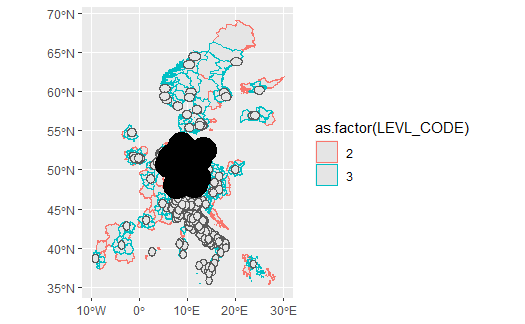

```r
# + Include all cities mentioned in umweltbundesamt as non-controls

ggplot(nuts.sf %>%
         filter(with_uar_60km == TRUE)) +
  geom_sf(aes(color = as.factor(LEVL_CODE))) +
  geom_sf(data = buffer_60_uar) +
  geom_sf(data = umweltzonen)
```

```r
  # geom_sf(data = nuts.sf_centroid, color = "red", size = 0.2)

# leaflet() %>%
#   addTiles() %>%
#   addPolygons(data = nuts.sf %>%
#                 filter(with_uar_80km == FALSE),
#               weight = 4, col = "red") %>%
#   addPolygons(data = buffer_80_uar, col = "green") %>%
#   addCircleMarkers(data = nuts.sf_centroid,
#              # clusterOptions = markerClusterOptions(),
#               popup = paste0(
#                 "<b>", nuts.sf_centroid$NUTS_ID, "</b> <br/>",
#                 "<b> Name: </b>",
#                 nuts.sf_centroid$NUTS_NAME, "<br/>"))
```

### Get list of treated:

Those NUTS regions that are INSIDE a OMS LEZ + those NUTS who are in the center of UAR (only LEZ) + Those NUTS who are in the center of g_zones + The geographical location of all cities named in Umweltbundesamt (Inagurated before XXX) - Restricted only to german cities (NUTS_ID starts by “DE”)

```r
# import OMS LEZ geographies:
lez_shapes <- read_sf("data/lez_data2") %>%
  st_make_valid()

## This is to try to avoid very "small" parts of a NUTS region inside a LEZ make them bain ategorized as "Treated". I could do this case by case too.
# temp <- lez_shapes %>%
#   st_transform(29902) %>% # Irish grid, that uses meters
#   st_snap(nuts.sf, tolerance = units::set_units(2, "km")) %>%
#   st_transform(crs = "+proj=longlat +datum=WGS84")

uar_sf_lez <- uar_sf %>% filter(lez == TRUE)

nuts.sf <- nuts.sf %>%
  mutate(
    treated_osm = ifelse(
      NUTS_ID %in%
        (st_intersection(
          nuts.sf, lez_shapes)$NUTS_ID %>%
           unique()),
      TRUE, FALSE),
    treated_uar = ifelse(
      NUTS_ID %in%
        (st_intersection(
          nuts.sf, uar_sf_lez)$NUTS_ID %>%
           unique()),
      TRUE, FALSE),
    treated_gz = ifelse(
      NUTS_ID %in%
        (st_intersection(
          nuts.sf, gzones_sf)$NUTS_ID %>%
           unique()),
      TRUE, FALSE),
    treated_uz = ifelse(
      NUTS_ID %in%
        (st_intersection(
          nuts.sf, umweltzonen)$NUTS_ID %>%
           unique()),
      TRUE, FALSE),
  ) %>% # That are inside Germany, if not they are NOT treated:
  mutate(
    treated_osm = ifelse(CNTR_CODE == "DE", treated_osm, FALSE),
    treated_uar = ifelse(CNTR_CODE == "DE", treated_uar, FALSE),
    treated_gz = ifelse(CNTR_CODE == "DE", treated_gz, FALSE),
    # treated_uz = ifelse(CNTR_CODE == "DE", treated_uz, FALSE)
  ) %>%
  mutate(
    treated_any = treated_osm | treated_uar | treated_gz | treated_uz
  )
```

[output not shown]

```r
# Treatment statuses mostly coincide
nuts.sf %>% as.data.frame() %>%
  select(treated_osm, treated_uar, treated_gz, treated_uz) %>%
  table()
```

```
, , treated_gz = FALSE, treated_uz = FALSE

           treated_uar
treated_osm FALSE TRUE
      FALSE  1758    0
      TRUE     10    8

, , treated_gz = TRUE, treated_uz = FALSE

           treated_uar
treated_osm FALSE TRUE
      FALSE     0    0
      TRUE      0    1

, , treated_gz = FALSE, treated_uz = TRUE

           treated_uar
treated_osm FALSE TRUE
      FALSE     0    2
      TRUE      0    2

, , treated_gz = TRUE, treated_uz = TRUE

           treated_uar
treated_osm FALSE TRUE
      FALSE     1   15
      TRUE      1   56
```

## 2 or 3 control statuses

```r
nuts.sf <- nuts.sf %>%
  mutate(
    contr_restr_point = case_when(
      with_umweltzonen_point ~ FALSE,
      with_gzones_point ~ FALSE,
      with_uar_point ~ FALSE,
      TRUE ~ TRUE # if none of the past conditions, it's a control
    ),
    contr_restr_30km = case_when(
      with_umweltzonen_30km ~ FALSE,
      with_gzones_30km ~ FALSE,
      with_uar_30km ~ FALSE,
      TRUE ~ TRUE # if none of the past conditions, it's a control
    ),
    contr_restr_60km = case_when(
      with_umweltzonen_60km ~ FALSE,
      with_gzones_60km ~ FALSE,
      with_uar_60km ~ FALSE,
      TRUE ~ TRUE # if none of the past conditions, it's a control
    )
  )
nuts.sf %>% names()
```

```
 [1] "LEVL_CODE"              "NUTS_ID"
 [3] "CNTR_CODE"              "NUTS_NAME"
 [5] "geometry"               "with_uar_point"
 [7] "with_uar_30km"          "with_uar_60km"
 [9] "with_gzones_point"      "with_gzones_30km"
[11] "with_gzones_60km"       "with_umweltzonen_point"
[13] "with_umweltzonen_30km"  "with_umweltzonen_60km"
[15] "treated_osm"            "treated_uar"
[17] "treated_gz"             "treated_uz"
[19] "treated_any"            "contr_restr_point"
[21] "contr_restr_30km"       "contr_restr_60km"
```

### Get degree of urbanization

- Modified in ArcGis fron LAU regions to NUTS 3 by taking the mean of (1, 2, 3) being urban, sub urban and rural.
- Source https://ec.europa.eu/eurostat/web/gisco/geodata/reference-data/population-distribution-demography/degurba#degurba01
- year: 2014

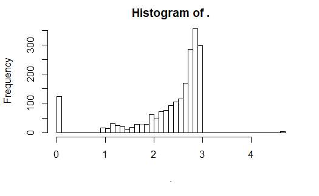

```r
nuts_urban <- st_read("data/arcgis/nuts_mean_urban.shp")
nuts_urban$DGUBA_CODE %>% hist(breaks = 45)
```

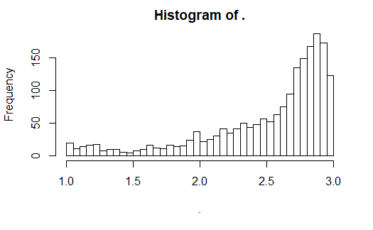

```r
nuts_urban <- nuts_urban %>%
  as.data.frame() %>% # Remove Spatial info
  mutate(DGUBA_CODE = ifelse(DGUBA_CODE > 3 | DGUBA_CODE == 0,
                             NA, DGUBA_CODE)) %>% # Drop NAs
  select(LEVL_CODE, NUTS_ID, CNTR_CODE, DGUBA_CODE) %>%
  arrange(NUTS_ID) %>%
  dplyr::rename(urb_index = DGUBA_CODE)

nuts_urban$urb_index %>% hist(breaks = 45)
```

```r
nuts_urban$urb_index %>% summary()
```

```
   Min. 1st Qu.  Median    Mean 3rd Qu.    Max.    NA's
  1.000   2.304   2.698   2.511   2.853   3.000     127
```

```r
# Include the variable into nuts.sf
nuts.sf <- nuts.sf %>%
  left_join(nuts_urban)
(nuts.sf %>% as.data.frame() %>% select(-geometry) %>%
  filter(treated_any == TRUE) %>%
  select(urb_index))$urb_index %>% summary()
```

```
   Min. 1st Qu.  Median    Mean 3rd Qu.    Max.
  1.167   1.847   2.150   2.158   2.548   2.897
```

```r
# 3rd quartile of urbanization index for treated is 2.548
```

Include all relevant data in nuts.sf and save it.

```r
# # Mark NUTS 3 regions that have a city or point marked in eather UAR or GZ
# nuts.sf <- nuts.sf %>%
#   mutate(
#     appl_uar = NUTS_ID %in% uar_points.sf_nuts$NUTS_ID,
#     appl_gz = NUTS_ID %in% gzones_sp.sf_nuts$NUTS_ID
#     # min_apl_date = gzones_sp.sf_nuts$min_time
#   ) %>%
#   left_join(min_time) %>%
#   select(-c("FID")) # duplicated

nuts.sf %>% names()
```

```
 [1] "LEVL_CODE"              "NUTS_ID"
 [3] "CNTR_CODE"              "NUTS_NAME"
 [5] "geometry"               "with_uar_point"
 [7] "with_uar_30km"          "with_uar_60km"
 [9] "with_gzones_point"      "with_gzones_30km"
[11] "with_gzones_60km"       "with_umweltzonen_point"
[13] "with_umweltzonen_30km"  "with_umweltzonen_60km"
[15] "treated_osm"            "treated_uar"
[17] "treated_gz"             "treated_uz"
[19] "treated_any"            "contr_restr_point"
[21] "contr_restr_30km"       "contr_restr_60km"
[23] "urb_index"
```

## Date of treatment and treatment status

```r
nuts.sf.treated <- nuts.sf %>%
  st_join(umweltzonen)
```

```
although coordinates are longitude/latitude, st_intersects assumes that they are planar
```

```r
# If there are multiple zones in a given NUTS region I get multiple observations of that region

nuts.sf.treated <- nuts.sf.treated %>%
  mutate(more_one_nuts = duplicated(NUTS_ID)) %>%
  # Avoid to delete Aachen (it has 2 zones implemented the same year so there is no need to eliminate it)
  filter(!(NUTS_ID == "DEA2D" & more_one_nuts == TRUE)) %>%
  # Avoid to delete Freiburg (it has 2 zones, freiburg is signifficantly bigger and it's applied before so it had not influence from the other one, the other one is deleted)
  filter(!(NUTS_ID == "DE13" & more_one_nuts == TRUE)) %>%
  dplyr::group_by(NUTS_ID) %>%
  dplyr::mutate(more_one_nuts = sum(more_one_nuts)) %>%
  ungroup()

# List of NUTS regions that have only one LEZ:
nuts.sf.treated %>%
  filter(!is.na(LEZ),
         more_one_nuts == 0) %>%
  # select(NUTS_ID, NUTS_NAME) %>%
  unique()
```

```
Simple feature collection with 66 features and 36 fields
geometry type:  MULTIPOLYGON
dimension:      XY
bbox:           xmin: 5.97673 ymin: 47.39365 xmax: 13.76002 ymax: 53.79478
geographic CRS: WGS 84
```

| LEVL_CODE | NUTS_ID | CNTR_CODE | NUTS_NAME | geometry | with_uar_point | with_uar_30km | with_uar_60km | with_gzones_point | with_gzones_30km | with_gzones_60km | with_umweltzonen_point | with_umweltzonen_30km | with_umweltzonen_60km | treated_osm | treated_uar | treated_gz | treated_uz | treated_any | contr_restr_point | contr_restr_30km | contr_restr_60km | urb_index | State | LEZ | simple_LEZ | Status | Stage_1 | Stage_2 | Stage_3 | … |
| --- | --- | --- | --- | --- | --- | --- | --- | --- | --- | --- | --- | --- | --- | --- | --- | --- | --- | --- | --- | --- | --- | --- | --- | --- | --- | --- | --- | --- | --- | --- |
| 2 | DE13 | DE | Freiburg |  | TRUE | TRUE | TRUE | TRUE | TRUE | TRUE | TRUE | TRUE | TRUE | TRUE | TRUE | TRUE | TRUE | TRUE | FALSE | FALSE | FALSE | 2.534442 | Baden-Württemberg | Freiburg | Freiburg | Stufe 3 | 01.01.2010 | 01.01.2012 | 01.01.2013 | … |
| 2 | DE21 | DE | Oberbayern |  | TRUE | TRUE | TRUE | TRUE | TRUE | TRUE | TRUE | TRUE | TRUE | TRUE | TRUE | TRUE | TRUE | TRUE | FALSE | FALSE | FALSE | 2.689103 | Bayern | München | München | Stufe 3 | 01.10.2008 | 01.10.2010 | 01.10.2012 | … |
| 2 | DE94 | DE | Weser-Ems |  | TRUE | TRUE | TRUE | TRUE | TRUE | TRUE | TRUE | TRUE | TRUE | TRUE | TRUE | TRUE | TRUE | TRUE | FALSE | FALSE | FALSE | 2.614094 | Niedersachsen | Osnabrück | Osnabrück | Stufe 3 | 04.01.2010 | 03.01.2011 | 03.01.2012 | … |
| 2 | DEA3 | DE | Münster |  | TRUE | TRUE | TRUE | TRUE | TRUE | TRUE | TRUE | TRUE | TRUE | TRUE | TRUE | TRUE | TRUE | TRUE | FALSE | FALSE | FALSE | 2.121951 | Nordrhein-Westfalen | Münster | Münster | Stufe 3 | 01.01.2010 | 01.01.2010 | 01.01.2015 | … |
| 2 | DE92 | DE | Hannover |  | TRUE | TRUE | TRUE | TRUE | TRUE | TRUE | TRUE | TRUE | TRUE | TRUE | TRUE | TRUE | TRUE | TRUE | FALSE | FALSE | FALSE | 2.696246 | Niedersachsen | Hannover | Hannover | Stufe 3 | 01.01.2008 | 01.01.2009 | 01.01.2010 | … |
| 2 | DE23 | DE | Oberpfalz |  | TRUE | TRUE | TRUE | FALSE | FALSE | FALSE | TRUE | TRUE | TRUE | FALSE | TRUE | FALSE | TRUE | TRUE | FALSE | FALSE | FALSE | 2.812500 | Bayern | Regensburg | Regensburg | Stufe 3 | 15.01.2018 | 15.01.2018 | 15.01.2018 | … |
| 2 | DEB3 | DE | Rheinhessen-Pfalz |  | TRUE | TRUE | TRUE | TRUE | TRUE | TRUE | TRUE | TRUE | TRUE | TRUE | TRUE | TRUE | TRUE | TRUE | FALSE | FALSE | FALSE | 2.665757 | Rheinland-Pfalz | Mainz | Mainz | Stufe 3 | 01.02.2013 | 01.02.2013 | 01.02.2013 | … |
| 2 | DE30 | DE | Berlin |  | TRUE | TRUE | TRUE | TRUE | TRUE | TRUE | TRUE | TRUE | TRUE | TRUE | TRUE | TRUE | TRUE | TRUE | FALSE | FALSE | FALSE | 2.037037 | Berlin | Berlin | Berlin | Stufe 3 | 01.01.2008 | 01.01.2010 | 01.01.2010 | … |
| 2 | DE50 | DE | Bremen |  | TRUE | TRUE | TRUE | TRUE | TRUE | TRUE | TRUE | TRUE | TRUE | TRUE | TRUE | TRUE | TRUE | TRUE | FALSE | FALSE | FALSE | 2.055556 | Bremen | Bremen | Bremen Mitte | Stufe 3 | 01.01.2009 | 01.01.2010 | 01.07.2011 | … |
| 2 | DEG0 | DE | Thüringen |  | TRUE | TRUE | TRUE | TRUE | TRUE | TRUE | TRUE | TRUE | TRUE | FALSE | TRUE | TRUE | TRUE | TRUE | FALSE | FALSE | FALSE | 2.897196 | Thüringen | Erfurt | Erfurt | Stufe 3 | 01.10.2012 | 01.10.2012 | 01.10.2012 | … |

[output cut: 56 more lines]

```r
# Delete those regions that have more than one NUTS
nuts.sf.treated <- nuts.sf.treated %>%
  filter(more_one_nuts == 0) %>%
  select(-more_one_nuts)

# nuts.sf.treated <- nuts.sf.treated %>%
#   group_by(NUTS_ID) %>%
#   mutate(
#     year_stage1 = as_date(Stage_1, format = "%d.%m.%Y") %>% year(),
#     year_stage2 = as_date(Stage_2, format = "%d.%m.%Y") %>% year(),
#     year_stage3 = as_date(Stage_3, format = "%d.%m.%Y") %>% year(),
#     year_announced = as_date(Announcment, format = "%d.%m.%Y") %>% year(),
#   ) %>%
#   ungroup()

nuts.sf.treated %>% head()
```

```
Simple feature collection with 6 features and 35 fields
geometry type:  MULTIPOLYGON
dimension:      XY
bbox:           xmin: 6.43275 ymin: 39.64495 xmax: 28.60746 ymax: 47.62081
geographic CRS: WGS 84
```

| LEVL_CODE | NUTS_ID | CNTR_CODE | NUTS_NAME | geometry | with_uar_point | with_uar_30km | with_uar_60km | with_gzones_point | with_gzones_30km | with_gzones_60km | with_umweltzonen_point | with_umweltzonen_30km | with_umweltzonen_60km | treated_osm | treated_uar | treated_gz | treated_uz | treated_any | contr_restr_point | contr_restr_30km | contr_restr_60km | urb_index | State | LEZ | simple_LEZ | Status | Stage_1 | Stage_2 | Stage_3 | … |
| --- | --- | --- | --- | --- | --- | --- | --- | --- | --- | --- | --- | --- | --- | --- | --- | --- | --- | --- | --- | --- | --- | --- | --- | --- | --- | --- | --- | --- | --- | --- |
| 3 | HR043 | HR | Krapinsko-zagorska županija |  | FALSE | FALSE | FALSE | FALSE | FALSE | FALSE | FALSE | FALSE | FALSE | FALSE | FALSE | FALSE | FALSE | FALSE | TRUE | TRUE | TRUE | 2.884615 | NA | NA | NA | NA | NA | NA | NA | … |
| 2 | CH02 | CH | Espace Mittelland |  | TRUE | TRUE | TRUE | FALSE | FALSE | TRUE | FALSE | FALSE | TRUE | FALSE | FALSE | FALSE | FALSE | FALSE | FALSE | FALSE | FALSE | 2.661166 | NA | NA | NA | NA | NA | NA | NA | … |
| 2 | CH03 | CH | Nordwestschweiz |  | FALSE | TRUE | TRUE | FALSE | FALSE | TRUE | FALSE | FALSE | TRUE | FALSE | FALSE | FALSE | FALSE | FALSE | TRUE | FALSE | FALSE | 2.313433 | NA | NA | NA | NA | NA | NA | NA | … |
| 2 | AL02 | AL | Qender |  | FALSE | FALSE | FALSE | FALSE | FALSE | FALSE | FALSE | FALSE | FALSE | FALSE | FALSE | FALSE | FALSE | FALSE | TRUE | TRUE | TRUE | 2.333333 | NA | NA | NA | NA | NA | NA | NA | … |
| 2 | AL03 | AL | Jug |  | FALSE | FALSE | FALSE | FALSE | FALSE | FALSE | FALSE | FALSE | FALSE | FALSE | FALSE | FALSE | FALSE | FALSE | TRUE | TRUE | TRUE | 2.800000 | NA | NA | NA | NA | NA | NA | NA | … |
| 2 | BG33 | BG |  |  | FALSE | FALSE | FALSE | FALSE | FALSE | FALSE | FALSE | FALSE | FALSE | FALSE | FALSE | FALSE | FALSE | FALSE | TRUE | TRUE | TRUE | 2.972940 | NA | NA | NA | NA | NA | NA | NA | … |

```r
nuts.sf.treated %>%
  # filter(str_detect(NUTS_NAME, "Freiburg")) %>%
  filter(NUTS_ID == "DEA3")
```

```
Simple feature collection with 1 feature and 35 fields
geometry type:  GEOMETRY
dimension:      XY
bbox:           xmin: 6.38762 ymin: 51.48127 xmax: 8.32014 ymax: 52.47402
geographic CRS: WGS 84
```

|  | LEVL_CODE | NUTS_ID | CNTR_CODE | NUTS_NAME | geometry | with_uar_point | with_uar_30km | with_uar_60km | with_gzones_point | with_gzones_30km | with_gzones_60km | with_umweltzonen_point | with_umweltzonen_30km | with_umweltzonen_60km | treated_osm | treated_uar | treated_gz | treated_uz | treated_any | contr_restr_point | contr_restr_30km | contr_restr_60km | urb_index | State | LEZ | simple_LEZ | Status | Stage_1 | Stage_2 | … |
| --- | --- | --- | --- | --- | --- | --- | --- | --- | --- | --- | --- | --- | --- | --- | --- | --- | --- | --- | --- | --- | --- | --- | --- | --- | --- | --- | --- | --- | --- | --- |
| 1 | 2 | DEA3 | DE | Münster |  | TRUE | TRUE | TRUE | TRUE | TRUE | TRUE | TRUE | TRUE | TRUE | TRUE | TRUE | TRUE | TRUE | TRUE | FALSE | FALSE | FALSE | 2.121951 | Nordrhein-Westfalen | Münster | Münster | Stufe 3 | 01.01.2010 | 01.01.2010 | … |

## Save the data

```r
saveRDS(nuts.sf, "data/nuts_sf")
```

```
cannot open file 'data/nuts_sf': it is a directoryError in gzfile(file, mode) : cannot open the connection
```

## Maps of T and C !

```r
temp_treated <- nuts.sf.treated %>%
  filter(treated_uz == TRUE,
         LEVL_CODE == 3)

temp_control <- nuts.sf.treated %>%
  filter(with_umweltzonen_60km == FALSE,
         LEVL_CODE == 3)

treated_and_controls <- leaflet() %>%
  addTiles() %>%
  addPolygons(data = temp_treated,
              popup = paste0(
                "<b>", temp_treated$NUTS_ID, "</b> <br/>",
                "<b> Nuts name: </b>",
                temp_treated$NUTS_NAME, "<br/>"),
              weight = 4, col = "red") %>%
  addPolygons(data = lez_shapes, col = "green") %>%
  addPolygons(data = temp_control,
              col = "blue",
              popup = paste0(
                "<b>", temp_control$NUTS_ID, "</b> <br/>",
                "<b> Name: </b>",
                temp_control$NUTS_NAME, "<br/>")) %>%
  # addMarkers(data = umweltzonen,
  #            popup = paste0(
  #              "<b>", umweltzonen$LEZ, "</b> <br/>",
  #              "<b> Start date: </b>", umweltzonen$Stage_1, "<br/>",
  #              "<b> Announcment date: </b>",
  #              umweltzonen$Announcment, "<br/>",
  #              "<b> Source: </b> Umweltzonen")) %>%
  setView(15, 50, zoom = 3)

treated_and_controls

# htmlwidgets::saveWidget(treated_and_controls,
#                         file="map_tr_and_controls_nomark.html")
```

For NUTS 2

```r
temp_treated <- nuts.sf.treated %>%
  filter(treated_any == TRUE,
         LEVL_CODE == 2)

temp_control <- nuts.sf.treated %>%
  filter(contr_restr_60km == TRUE,
         LEVL_CODE == 2)

treated_and_controls_2 <- leaflet() %>%
  addTiles() %>%
  addPolygons(data = temp_treated,
              popup = paste0(
                "<b>", temp_treated$NUTS_ID, "</b> <br/>",
                "<b> Start date: </b>",
                temp_treated$NUTS_NAME, "<br/>"),
              weight = 4, col = "red") %>%
  addPolygons(data = lez_shapes, col = "green") %>%
  addPolygons(data = temp_control,
              col = "blue",
              popup = paste0(
                "<b>", temp_control$NUTS_ID, "</b> <br/>",
                "<b> Name: </b>",
                temp_control$NUTS_NAME, "<br/>")
              ) %>%
  addMarkers(data = umweltzonen,
             popup = paste0(
               "<b>", umweltzonen$LEZ, "</b> <br/>",
               "<b> Start date: </b>", umweltzonen$Stage_1, "<br/>",
               "<b> Source: </b> Umweltzonen")) %>%
  setView(15, 50, zoom = 3)

# treated_and_controls_2

# htmlwidgets::saveWidget(treated_and_controls_2,
#                         file="map_tr_and_controls_n2.html")
```

For NUTS 2 (point)

```r
temp_treated <- nuts.sf.treated %>%
  filter(treated_any == TRUE,
         LEVL_CODE == 2)

temp_control <- nuts.sf.treated %>%
  filter(contr_restr_point == TRUE,
         LEVL_CODE == 2)

treated_and_controls_2_point <- leaflet() %>%
  addTiles() %>%
  addPolygons(data = temp_treated,
              popup = paste0(
                "<b>", temp_treated$NUTS_ID, "</b> <br/>",
                "<b> Start date: </b>",
                temp_treated$NUTS_NAME, "<br/>"),
              weight = 4, col = "red") %>%
  addPolygons(data = lez_shapes, col = "green") %>%
  addPolygons(data = temp_control,
              col = "blue",
              popup = paste0(
                "<b>", temp_control$NUTS_ID, "</b> <br/>",
                "<b> Name: </b>",
                temp_control$NUTS_NAME, "<br/>")
              ) %>%
  addMarkers(data = umweltzonen,
             popup = paste0(
               "<b>", umweltzonen$LEZ, "</b> <br/>",
               "<b> Start date: </b>", umweltzonen$Stage_1, "<br/>",
               "<b> Source: </b> Umweltzonen")) %>%
  setView(15, 50, zoom = 3)

# treated_and_controls_2_30

htmlwidgets::saveWidget(treated_and_controls_2_point,
                        file="map_tr_and_controls_n2_point.html")
```

end